# Analysis of BSL corpus questions

Bodo Winter

02/06/2020

## Setup

Analysis of questions in the BSL corpus. Sections labeled **turning point** exclude data which means that everything from that section onward will be a subset analysis.

The analysis has two turning points: - `semantic types`: from that point onwards, all analyses focus on polar versus content questions - `constructed actions`: from that point onwards, all analyses focus on the non-CA dataset

Load packages:

```r
library(tidyverse)
library(lsr) # for Cramer's V effect size
library(patchwork) # for multiplotting
```

Check R version and package version for reporting:

```r
R.Version()
```

```
## $platform
## [1] "x86_64-apple-darwin20"
##
## $arch
## [1] "x86_64"
##
## $os
## [1] "darwin20"
##
## $system
## [1] "x86_64, darwin20"
##
## $status
## [1] ""
##
## $major
## [1] "4"
##
## $minor
## [1] "3.0"
##
## $year
## [1] "2023"
##
## $month
## [1] "04"
##
## $day
## [1] "21"
##
## $`svn rev`
## [1] "84292"
##
## $language
## [1] "R"
##
## $version.string
## [1] "R version 4.3.0 (2023-04-21)"
##
## $nickname
## [1] "Already Tomorrow"
```

```r
packageVersion('tidyverse')
```

```
## [1] '2.0.0'
```

```r
packageVersion('lsr')
```

```
## [1] '0.5.2'
```

```r
packageVersion('patchwork')
```

```
## [1] '1.1.2'
```

Load helper functions. Loading this makes the new functions `proportion()` and `percentage()` available, which I wrote because this project requires lots of calculation of proportions and percentages on the basis of contigency tables. The custom function `prop_table()` then uses both of these functions to create a table of proportions and percentages. It takes an object resulting from `count()` as input.

Sourcing this .R script also makes the ggplot2 theme `theme_BSL()` available, which is an extension of `theme_classic()` with some project-specific cosmetic tweaks.

```r
source('question_helper_functions.R')
```

Load cleaned data, which is the output from the `preprocessing.Rmd` script:

```r
df <- read_csv('../data/BSL_questions_cleaned.csv')
```

## Overview

Let’s start by getting an overview of the dataset, which will also be used for reporting in the paper.

How many data points in total?

```r
nrow(df)
```

```
## [1] 726
```

726 observations (tokens).

How many participants are there?

```r
count(df, ppt_id) %>%
  nrow()
```

```
## [1] 40
```

How many data points per participant?

```r
count(df, ppt_id, sort = TRUE) %>%
  print(n = Inf)
```

```
## # A tibble: 40 × 2
##    ppt_id     n
##    <chr>  <int>
##  1 BM06      44
##  2 LN04      35
##  3 MC24      35
##  4 MC23      31
##  5 MC27      31
##  6 MC10      29
##  7 BM13      27
##  8 BM21      25
##  9 LN24      24
## 10 BM05      23
## 11 LN23      22
## 12 BL10      21
```

[output cut: 28 more lines]

What is the average number of data points per participant? What’s the maximum and minimum number of data points per participant?

```r
count(df, ppt_id) %>%
  summarize(average_N = mean(n),
            min = min(n),
            max = max(n))
```

```
## # A tibble: 1 × 3
##   average_N   min   max
##       <dbl> <int> <int>
## 1      18.2     5    44
```

How many participants do we have per gender?

```r
distinct(df, ppt_id, gender) %>%
  count(gender)
```

```
## # A tibble: 2 × 2
##   gender     n
##   <chr>  <int>
## 1 F         20
## 2 M         20
```

20 women, 20 men.

What’s the mean age and age range?

```r
df %>%
  group_by(ppt_id) %>%
  summarize(participant_age = mean(age)) %>%
  ungroup() %>%
  summarize(age_M = mean(participant_age),
            age_SD = sd(participant_age),
            min_age = min(participant_age),
            max_age = max(participant_age))
```

```
## # A tibble: 1 × 4
##   age_M age_SD min_age max_age
##   <dbl>  <dbl>   <dbl>   <dbl>
## 1  47.8   17.8      17      77
```

How many per ethnicity, city, handedness and family?

```r
# Ethnicity:

distinct(df, ppt_id, ethnicity) %>%
  count(ethnicity) %>%
  prop_table()
```

```
## # A tibble: 3 × 5
##   ethnicity     n proportion percent N
##   <chr>     <int>      <dbl> <chr>   <chr>
## 1 Asian         1       0.03 3%      N = 1
## 2 Black         3       0.07 7%      N = 3
## 3 White        36       0.9  90%     N = 36
```

```r
# Family:

distinct(df, ppt_id, family) %>%
  count(family) %>%
  prop_table()
```

```
## # A tibble: 2 × 5
##   family      n proportion percent N
##   <chr>   <int>      <dbl> <chr>   <chr>
## 1 Deaf       16        0.4 40%     N = 16
## 2 Hearing    24        0.6 60%     N = 24
```

```r
# Handedness:

distinct(df, ppt_id, handedness) %>%
  count(handedness) %>%
  prop_table()
```

```
## # A tibble: 2 × 5
##   handedness       n proportion percent N
##   <chr>        <int>      <dbl> <chr>   <chr>
## 1 left-handed      3       0.07 7%      N = 3
## 2 right-handed    37       0.92 92%     N = 37
```

## Syntactic context

In this section, we will look at the syntactic context.

```r
count(df, clu_composite, sort = TRUE) %>%
  prop_table()
```

```
## # A tibble: 18 × 5
##    clu_composite           n proportion percent N
##    <chr>               <int>      <dbl> <chr>   <chr>
##  1 Single                546       0.75 75%     N = 546
##  2 Embed                  55       0.08 8%      N = 55
##  3 SharedCecho            34       0.05 5%      N = 34
##  4 Fragment               31       0.04 4%      N = 31
##  5 Single?                15       0.02 2%      N = 15
##  6 Depend                 14       0.02 2%      N = 14
##  7 Embed?                  6       0.01 1%      N = 6
##  8 Single, Single          6       0.01 1%      N = 6
##  9 SharedCcontent          4       0.01 1%      N = 4
## 10 EmbedDepend             3       0    0%      N = 3
## 11 EmbedDepend?            3       0    0%      N = 3
## 12 Depend?                 2       0    0%      N = 2
## 13 EmbedEmbed              2       0    0%      N = 2
## 14 Embed, Single           1       0    0%      N = 1
## 15 Fragment?               1       0    0%      N = 1
## 16 SharedMcontentEmbed     1       0    0%      N = 1
## 17 Single, Single?         1       0    0%      N = 1
## 18 Single?, Single?        1       0    0%      N = 1
```

Tabulate the number of certain and uncertain `clu_composite` tokens:

```r
# Create variable that detects presence/absence of question mark:

df <- mutate(df,
             clu_certainty = ifelse(str_detect(clu_composite, '\\?'),
                                    'contains_uncertain', 'certain'))

# Count certain versus uncertain tokens:

df %>%
  count(clu_certainty) %>%
  mutate(prop = proportion(n),
         perc = percentage(n))
```

```
## # A tibble: 2 × 4
##   clu_certainty          n  prop perc
##   <chr>              <int> <dbl> <chr>
## 1 certain              697  0.96 96%
## 2 contains_uncertain    29  0.04 4%
```

Here, “Embed”, “Single, Single”, “Embed, Single”, “EmbedEmbed”, “EmbedDepend”, “SharedMcontentEmbed”, are collapsed to “complex”. The resulting `clu_composite` variable will also get rid of the question mark (uncertain cases) to tabulate this:

```r
df <- mutate(df,
             clu_cleaned = clu_composite,
             clu_cleaned = ifelse(str_detect(clu_composite, '\\?'),
                                  'uncertain', clu_composite),
             clu_cleaned = ifelse(clu_cleaned == 'Embed',
                                  'complex', clu_cleaned),
             clu_cleaned = ifelse(clu_cleaned == 'Depend',
                                  'complex', clu_cleaned),
             clu_cleaned = ifelse(clu_cleaned == 'Single, Single',
                                  'complex', clu_cleaned),
             clu_cleaned = ifelse(clu_cleaned == 'EmbedDepend',
                                  'complex', clu_cleaned),
             clu_cleaned = ifelse(clu_cleaned == 'EmbedEmbed',
                                  'complex', clu_cleaned),
             clu_cleaned = ifelse(clu_cleaned == 'Embed, Single',
                                  'complex', clu_cleaned),
             clu_cleaned = ifelse(clu_cleaned == 'SharedMcontentEmbed',
                                  'complex', clu_cleaned),
             clu_cleaned = ifelse(clu_cleaned == 'SharedCcontent',
                                  'shared', clu_cleaned),
             clu_cleaned = ifelse(clu_cleaned == 'SharedCecho',
                                  'shared', clu_cleaned))

# Double check:

df %>%
  count(clu_cleaned, sort = TRUE) %>%
  prop_table()
```

```
## # A tibble: 5 × 5
##   clu_cleaned     n proportion percent N
##   <chr>       <int>      <dbl> <chr>   <chr>
## 1 Single        546       0.75 75%     N = 546
## 2 complex        82       0.11 11%     N = 82
## 3 shared         38       0.05 5%      N = 38
## 4 Fragment       31       0.04 4%      N = 31
## 5 uncertain      29       0.04 4%      N = 29
```

## Constructed actions (turning point)

Constructed actions will be excluded from the analysis. We’ll look at this separately later in a different script. But first we need to report how many occurred with constructed actions:

```r
CA_counts <- count(df, has_CA) %>%
  prop_table()

# Change labels:

CA_counts <- mutate(CA_counts,
                    has_CA = ifelse(has_CA == 'has CA',
                                    'constructed action',
                                    'no constructed action'))


# Show:

CA_counts
```

```
## # A tibble: 2 × 5
##   has_CA                    n proportion percent N
##   <chr>                 <int>      <dbl> <chr>   <chr>
## 1 constructed action      103       0.14 14%     N = 103
## 2 no constructed action   623       0.86 86%     N = 623
```

Only 14% of the data has constructed actions, but that’s at a whopping 103 tokens.

Graph of presence/absence of constructed action here since this will be excluded after:

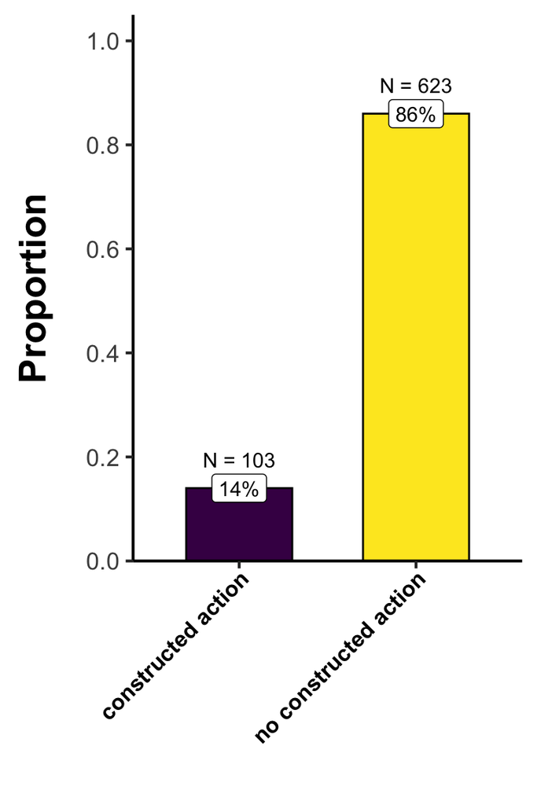

```r
# Data and aesthetics:

CA_p <- CA_counts %>%
  ggplot(aes(x = reorder(has_CA, proportion),
             y = proportion,
             fill = reorder(has_CA, proportion)))

# Add geoms:

CA_p <- CA_p +
  geom_bar(stat = 'identity', col = 'black', width = 0.6) +
  geom_text(aes(label = N),
            nudge_y = 0.055) +
  geom_label(aes(label = percent),
             nudge_y = 0.0, fill = 'white')

# Add other plot features:

CA_p <- CA_p +
  scale_fill_viridis_d() +
  scale_y_continuous(breaks = seq(0, 1.0, 0.2),
                     limits = c(0, 1.05),
                     expand = c(0, 0)) +
  xlab('') +
  ylab('Proportion') +
  theme_BSL_45()

# Plot & save plot:

CA_p
```

```r
ggsave(plot = CA_p,
       file = '../figures/pdf/constructed_action.pdf',
       width = 3.5, height = 6)
ggsave(plot = CA_p,
       file = '../figures/png/constructed_action.png',
       width = 3.5, height = 6)
```

**Turning point**:

Override the `df` tibble to be without constructed actions:

```r
df <- filter(df, has_CA == 'no CA')
```

How many are left?

```r
nrow(df)
```

```
## [1] 623
```

## Semantic types (turning point)

We will first look at semantic types because after this, we will focus the analysis on polar versus content questions:

Plot of semantic types:

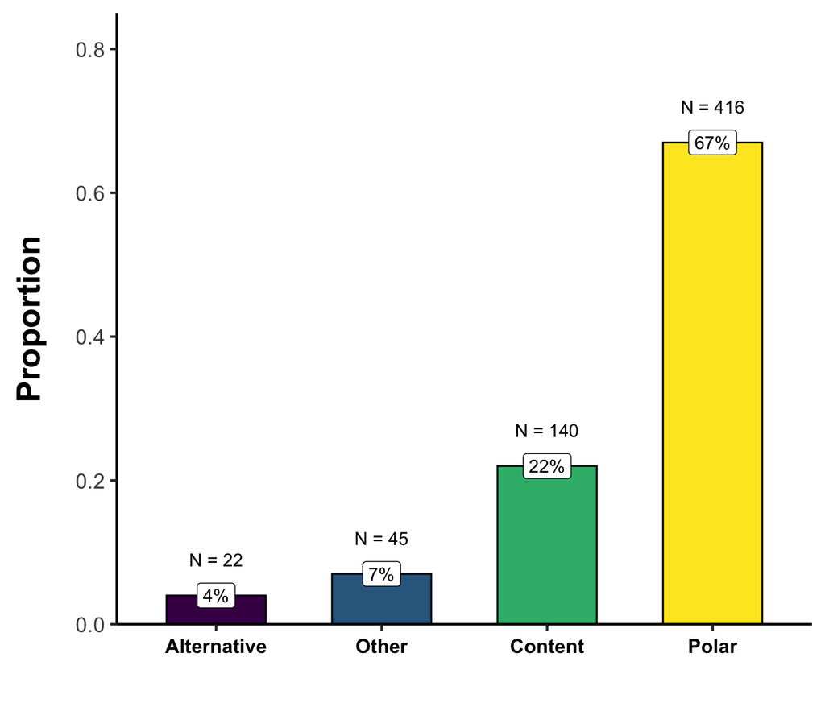

```r
# Data and aesthetics:

semantic_p <- df %>%
  count(semantic, sort = TRUE) %>%
  prop_table() %>%
  ggplot(aes(x = reorder(semantic, proportion),
             y = proportion,
             fill = reorder(semantic, proportion)))

# Add geoms:

semantic_p <- semantic_p +
  geom_bar(stat = 'identity',
           col = 'black', width = 0.6) +
  geom_text(aes(label = N),
            nudge_y = 0.05) +
  geom_label(aes(label = percent),
             nudge_y = 0.0, fill = 'white')

# Add other plot features:

semantic_p <- semantic_p +
  scale_fill_viridis_d() +
  scale_y_continuous(breaks = seq(0, 1.0, 0.2),
                     limits = c(0, 0.85),
                     expand = c(0, 0)) +
  xlab('') +
  ylab('Proportion') +
  theme_BSL()

# Plot & save plot:

semantic_p
```

```r
ggsave(plot = semantic_p,
       file = '../figures/pdf/semantic.pdf',
       width = 7.5, height = 4.5)
ggsave(plot = semantic_p,
       file = '../figures/png/semantic.png',
       width = 7.5, height = 4.5)
```

**Turning point**:

From this point onwards, we’ll only focus on polar versus content questions:

```r
df <- filter(df,
             semantic %in% c('Content', 'Polar'))
```

How man are left?

```r
nrow(df) # 556 tokens left
```

```
## [1] 556
```

## Manual and non-manual signalling

Check nonmanuals by polar v content question:

```r
nonmanual_tab <- df %>%
  count(semantic, nonmanual) %>%
  group_by(semantic) %>%
  prop_table()

# Show:

nonmanual_tab
```

```
## # A tibble: 4 × 6
## # Groups:   semantic [2]
##   semantic nonmanual     n proportion percent N
##   <chr>    <chr>     <int>      <dbl> <chr>   <chr>
## 1 Content  Absent        5       0.04 4%      N = 5
## 2 Content  Present     135       0.96 96%     N = 135
## 3 Polar    Absent        7       0.02 2%      N = 7
## 4 Polar    Present     409       0.98 98%     N = 409
```

Check manuals by polar v content question:

```r
manual_tab <- df %>%
  count(semantic, manual) %>%
  group_by(semantic) %>%
  prop_table()

# Show:

manual_tab
```

```
## # A tibble: 6 × 6
## # Groups:   semantic [2]
##   semantic manual       n proportion percent N
##   <chr>    <chr>    <int>      <dbl> <chr>   <chr>
## 1 Content  Absent      34       0.24 24%     N = 34
## 2 Content  Multiple    30       0.21 21%     N = 30
## 3 Content  Single      76       0.54 54%     N = 76
## 4 Polar    Absent     357       0.86 86%     N = 357
## 5 Polar    Multiple    15       0.04 4%      N = 15
## 6 Polar    Single      44       0.11 11%     N = 44
```

Stacked bar plot for presence of non-manual signaling by semantic type:

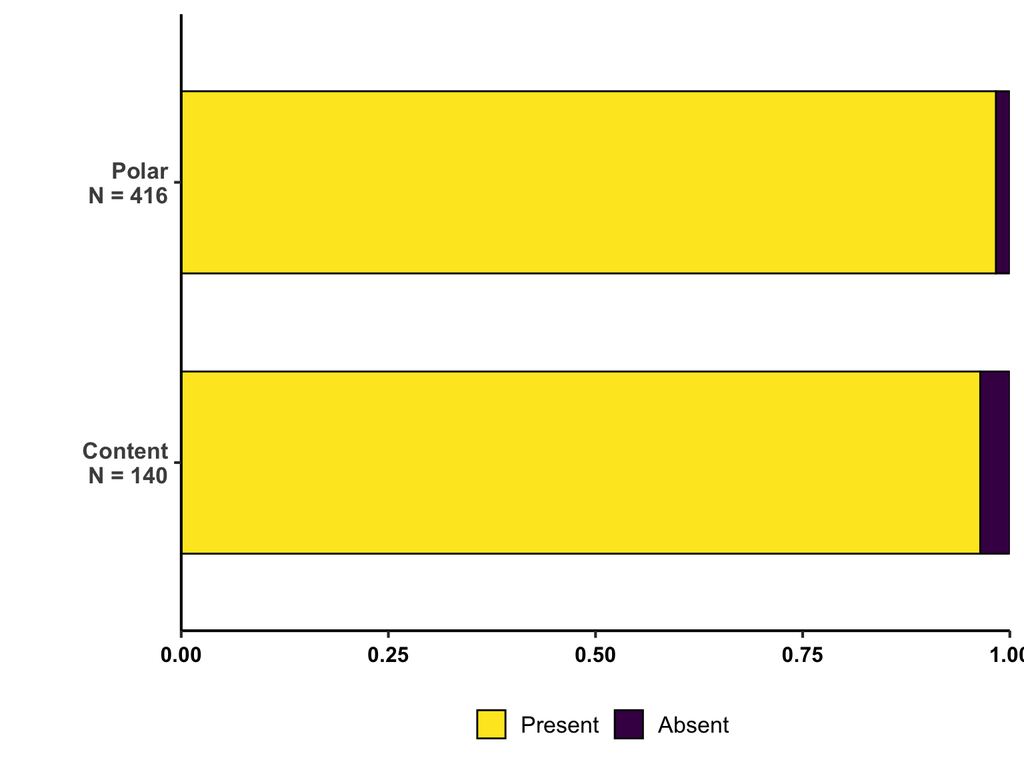

```r
# Aesthetics, geoms, and coord_flip():

nonmanual_p <- nonmanual_tab %>%
  mutate(semantic = ifelse(semantic == 'Content',
                           'Content\nN = 140',
                           'Polar\nN = 416')) %>%
  ggplot(aes(x = semantic,
             y = n, fill = nonmanual)) +
    geom_col(position = 'fill',
             width = 0.65, col = 'black') +
    coord_flip() +
    scale_fill_viridis_d(guide = guide_legend(reverse = TRUE))

# Cosmetic characteristics:

nonmanual_p <- nonmanual_p +
  xlab('') +
  ylab(NULL) +
  scale_y_continuous(expand = c(0, 0)) +
  theme_BSL() +
  theme(legend.position = 'bottom',
        legend.title = element_blank(),
        axis.text.y = element_text(face = 'bold'))

# Show plot (not save because will be combined):

nonmanual_p
```

Create a similar stacked bar plot for how manual signalling depends on semantic type:

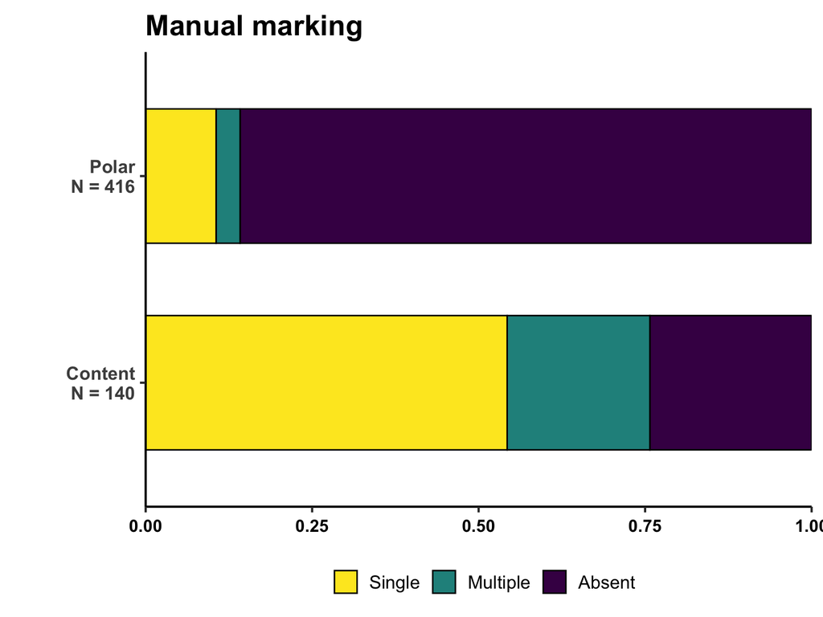

```r
# Aesthetics, geoms, and coord_flip():

manual_p <- manual_tab %>%
  mutate(semantic = ifelse(semantic == 'Content',
                           'Content\nN = 140', 'Polar\nN = 416')) %>%
  ggplot(aes(x = semantic, y = n, fill = manual)) +
    geom_col(position = 'fill', width = 0.65, col = 'black') +
    coord_flip() +
    scale_fill_viridis_d(guide = guide_legend(reverse = TRUE))

# Cosmetic characteristics:

manual_p <- manual_p +
  xlab('') +
  ylab(NULL) +
  scale_y_continuous(expand = c(0, 0)) +
  theme_BSL() +
  theme(legend.position = 'bottom',
        legend.title = element_blank(),
        axis.text.y = element_text(face = 'bold')) +
  ggtitle('Manual marking')

# Show and save plot:

manual_p
```

Combine manual and non-manual marking into one double plot:

```r
# Add a) b) titles for double plot:

nonmanual_p <- nonmanual_p +
  ggtitle('(a) Non-manual')
manual_p <- manual_p +
  ggtitle('(b) Manual')

# Put plots together:

fig2 <- nonmanual_p +
  plot_spacer() +
  manual_p +
  plot_layout(widths = c(20, 0.5, 20), nrow = 1)

# Save:

ggsave(plot = fig2,
       filename = '../figures/pdf/figure2.pdf',
       width = 13, height = 3.5)
ggsave(plot = fig2,
       filename = '../figures/png/figure2.png',
       width = 13, height = 3.5)
```

## Mouthing and mouth gestures

Check nonmanuals by polar v content question:

```r
mouthing_tab <- df %>%
  count(semantic, mouthing_question) %>%
  group_by(semantic) %>%
  prop_table()

# Show:

mouthing_tab
```

```
## # A tibble: 5 × 6
## # Groups:   semantic [2]
##   semantic mouthing_question     n proportion percent N
##   <chr>    <chr>             <int>      <dbl> <chr>   <chr>
## 1 Content  Absent               35       0.25 25%     N = 35
## 2 Content  Multiple             18       0.13 13%     N = 18
## 3 Content  Single               87       0.62 62%     N = 87
## 4 Polar    Absent              403       0.97 97%     N = 403
## 5 Polar    Single               13       0.03 3%      N = 13
```

Check mouth gestures by polar v content question:

```r
mouth_gestures_tab <- df %>%
  count(semantic, mouth_gesture_question) %>%
  group_by(semantic) %>%
  prop_table()

# Show:

mouth_gestures_tab
```

```
## # A tibble: 4 × 6
## # Groups:   semantic [2]
##   semantic mouth_gesture_question     n proportion percent N
##   <chr>    <chr>                  <int>      <dbl> <chr>   <chr>
## 1 Content  no                       130       0.93 93%     N = 130
## 2 Content  yes                       10       0.07 7%      N = 10
## 3 Polar    no                       401       0.96 96%     N = 401
## 4 Polar    yes                       15       0.04 4%      N = 15
```

Stacked bar plot for mouthings as a function of polar v content:

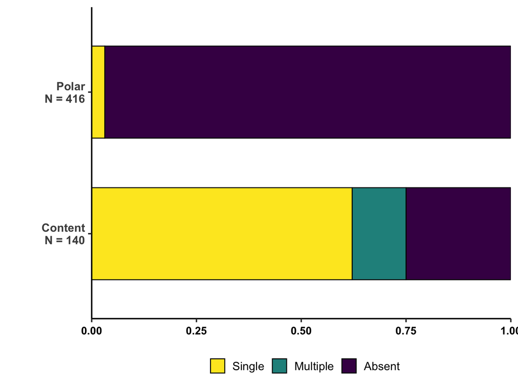

```r
# Aesthetics, geoms, and coord_flip():

mouthing_p <- mouthing_tab %>%
  mutate(semantic = ifelse(semantic == 'Content',
                           'Content\nN = 140',
                           'Polar\nN = 416')) %>%
  ggplot(aes(x = semantic, y = n, fill = mouthing_question)) +
  geom_col(position = 'fill', width = 0.65, col = 'black') +
  coord_flip() +
  scale_fill_viridis_d(guide = guide_legend(reverse = TRUE))

# Cosmetic characteristics:

mouthing_p <- mouthing_p +
  xlab('') +
  ylab(NULL) +
  scale_y_continuous(expand = c(0, 0)) +
  theme_BSL() +
  theme(legend.position = 'bottom',
        legend.title = element_blank(),
        axis.text.y = element_text(face = 'bold'))

# Show plot:

mouthing_p
```

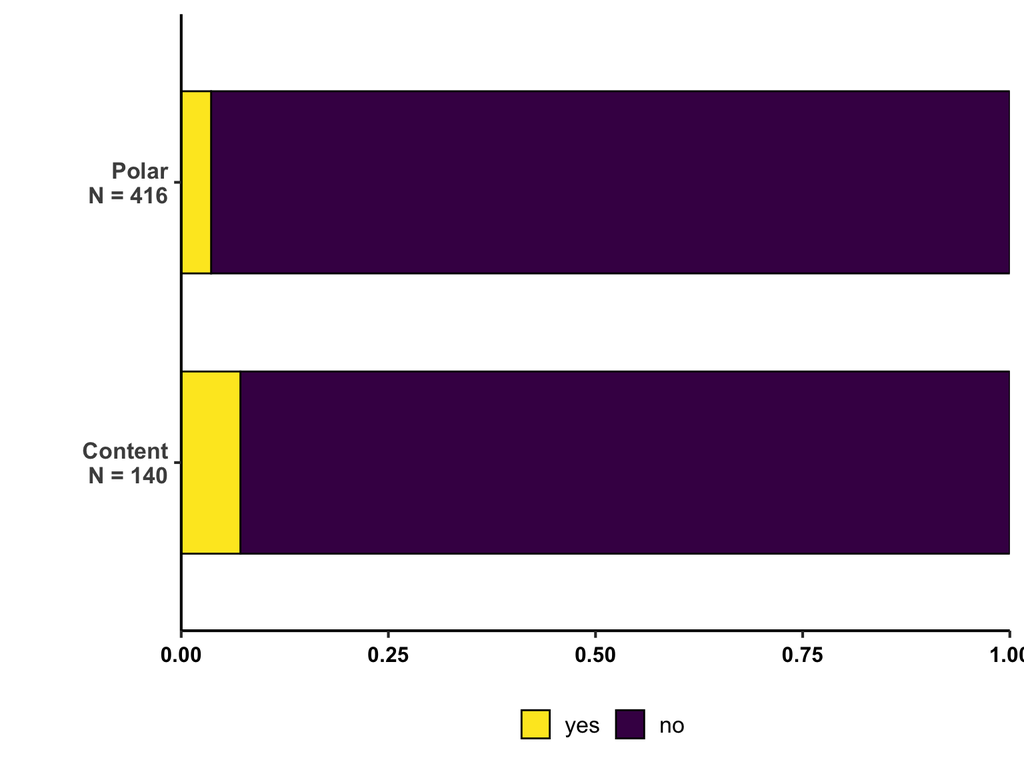

```r
# Aesthetics, geoms, and coord_flip():

mouth_gestures_p <- mouth_gestures_tab %>%
  mutate(semantic = ifelse(semantic == 'Content',
                           'Content\nN = 140',
                           'Polar\nN = 416')) %>%
  ggplot(aes(x = semantic, y = n,
             fill = mouth_gesture_question)) +
  geom_col(position = 'fill',
           width = 0.65, col = 'black') +
  coord_flip() +
  scale_fill_viridis_d(guide = guide_legend(reverse = TRUE))

# Cosmetic characteristics:

mouth_gestures_p <- mouth_gestures_p +
  xlab('') +
  ylab(NULL) +
  scale_y_continuous(expand = c(0, 0)) +
  theme_BSL() +
  theme(legend.position = 'bottom',
        legend.title = element_blank(),
        axis.text.y = element_text(face = 'bold'))

# Show and save plot:

mouth_gestures_p
```

Double plot combining mouthing and mouth gestures:

```r
# New titles with a) and b):

mouthing_p <- mouthing_p +
  ggtitle('(a) Mouthing')
mouth_gestures_p <- mouth_gestures_p +
  ggtitle('(b) Mouth gestures')

# Combine:

fig3 <- mouthing_p +
  plot_spacer() +
  mouth_gestures_p +
  plot_layout(widths = c(20, 0.5, 20), nrow = 1)

ggsave(plot = fig3,
       filename = '../figures/pdf/figure3.pdf',
       width = 13, height = 3.5)
ggsave(plot = fig3,
       filename = '../figures/png/figure3.png',
       width = 13, height = 3.5)
```

## Eyes, brows, and head

First, check all eye brow categories:

```r
df %>%
  count(eye_n_brow, sort = TRUE) %>%
  prop_table() %>%
  print(n = Inf)
```

```
## # A tibble: 39 × 5
##    eye_n_brow                 n proportion percent N
##    <chr>                  <int>      <dbl> <chr>   <chr>
##  1 up                       176       0.32 32%     N = 176
##  2 down                     117       0.21 21%     N = 117
##  3 null                      89       0.16 16%     N = 89
##  4 squint                    43       0.08 8%      N = 43
##  5 wide                      17       0.03 3%      N = 17
##  6 down, up                  12       0.02 2%      N = 12
##  7 null, up                  12       0.02 2%      N = 12
##  8 null, down                10       0.02 2%      N = 10
##  9 up, null                  10       0.02 2%      N = 10
## 10 down, null                 7       0.01 1%      N = 7
## 11 not visible                7       0.01 1%      N = 7
## 12 null, squint               6       0.01 1%      N = 6
```

[output cut: 27 more lines]

Transform the variable into one that has “single”, “multiple” or “no” head movements. First, define vectors for that:

```r
single <- c('up',
            'down',
            'squint',
            'wide',
            'null, up', # with null
            'null, down', # with null
            'null, squint', # with null
            'up, null', # with null
            'down, null', # with null
            'null, up, null', # with null
            'squint, null', # with null
            'null, down, null', # with null
            'null, squint, null') # with null

multiple <- c('down, up',
              'up, down',
              'up, squint',
              'squint, up',
              'up, down, up',
              'down, up, down',
              'down+squint',
              'down, down',
              'down, squint, null',
              'down, up, up, up, down',
              'down, wide, up',
              'null, down, up',
              'null, up, down',
              'null, up, null, up',
              'squint, squint',
              'squint, squint, null',
              'up, down, null',
              'up, null, down',
              'up, up',
              'up+squint',
              'up+squint, null',
              'up+wide',
              'up+wide, null')

none <- c('neutral', 'null')
```

Then, create a new variable that has a transformed variable:

```r
df$eye_clean <- NA

df <- mutate(df,
             eye_clean = ifelse(eye_n_brow %in% single, 'single', eye_clean),
             eye_clean = ifelse(eye_n_brow %in% multiple, 'multiple', eye_clean),
             eye_clean = ifelse(eye_n_brow %in% none, 'none', eye_clean))
```

Check:

```r
df %>% count(eye_n_brow, eye_clean) %>%
  print(n = Inf)
```

```
## # A tibble: 39 × 3
##    eye_n_brow             eye_clean     n
##    <chr>                  <chr>     <int>
##  1 down                   single      117
##  2 down+squint            multiple      2
##  3 down, down             multiple      1
##  4 down, null             single        7
##  5 down, squint, null     multiple      1
##  6 down, up               multiple     12
##  7 down, up, down         multiple      2
##  8 down, up, up, up, down multiple      1
##  9 down, wide, up         multiple      1
## 10 neutral                none          1
## 11 not visible            <NA>          7
## 12 null                   none         89
```

[output cut: 27 more lines]

Make a table for the cleaned and simplified eye brow variable:

```r
df %>%
  count(eye_clean, sort = TRUE) %>%
  prop_table() %>%
  print(n = Inf)
```

```
## # A tibble: 4 × 5
##   eye_clean     n proportion percent N
##   <chr>     <int>      <dbl> <chr>   <chr>
## 1 single      410       0.74 74%     N = 410
## 2 none         90       0.16 16%     N = 90
## 3 multiple     49       0.09 9%      N = 49
## 4 <NA>          7       0.01 1%      N = 7
```

Then, transform the eye brow variable into one that is either ‘up’, ‘down’ or ‘neither’. We convert cases like ‘up, null’ or ‘null, down ’to ’up’ and ‘down’ respectively etc. This is to look at the specific movements, and whether they differ between polar and content.

```r
singles_tab <- df %>%
  filter(eye_clean == 'single') %>%
  mutate(eye_n_brow = str_replace_all(eye_n_brow, '(, null)|(null, )', '')) %>%
  count(semantic, eye_n_brow) %>%
  filter(eye_n_brow %in% c('up', 'down', 'squint')) %>%
  group_by(semantic) %>%
  prop_table()

# Show:

singles_tab
```

```
## # A tibble: 6 × 6
## # Groups:   semantic [2]
##   semantic eye_n_brow     n proportion percent N
##   <chr>    <chr>      <int>      <dbl> <chr>   <chr>
## 1 Content  down          61       0.58 58%     N = 61
## 2 Content  squint         8       0.08 8%      N = 8
## 3 Content  up            37       0.35 35%     N = 37
## 4 Polar    down          75       0.26 26%     N = 75
## 5 Polar    squint        46       0.16 16%     N = 46
## 6 Polar    up           166       0.58 58%     N = 166
```

This is the new classification:

```r
eyes_tab <- df %>%
  count(semantic, eye_clean) %>%
  filter(!is.na(eye_clean)) %>% # get rid of NA's
  group_by(semantic) %>%
  prop_table()

# Show:

eyes_tab
```

```
## # A tibble: 6 × 6
## # Groups:   semantic [2]
##   semantic eye_clean     n proportion percent N
##   <chr>    <chr>     <int>      <dbl> <chr>   <chr>
## 1 Content  multiple      6       0.04 4%      N = 6
## 2 Content  none         24       0.18 18%     N = 24
## 3 Content  single      107       0.78 78%     N = 107
## 4 Polar    multiple     43       0.1  10%     N = 43
## 5 Polar    none         66       0.16 16%     N = 66
## 6 Polar    single      303       0.74 74%     N = 303
```

Check for the presence of squints:

```r
squint_tab <- df %>%
  count(semantic, any_eye_brow_squint) %>%
  group_by(semantic) %>%
  prop_table()

# Show:

squint_tab
```

```
## # A tibble: 4 × 6
## # Groups:   semantic [2]
##   semantic any_eye_brow_squint     n proportion percent N
##   <chr>    <chr>               <int>      <dbl> <chr>   <chr>
## 1 Content  no                    131       0.94 94%     N = 131
## 2 Content  yes                     9       0.06 6%      N = 9
## 3 Polar    no                    356       0.86 86%     N = 356
## 4 Polar    yes                    60       0.14 14%     N = 60
```

Stacked bar plot for eye and eye brow movements as a function of polar v content:

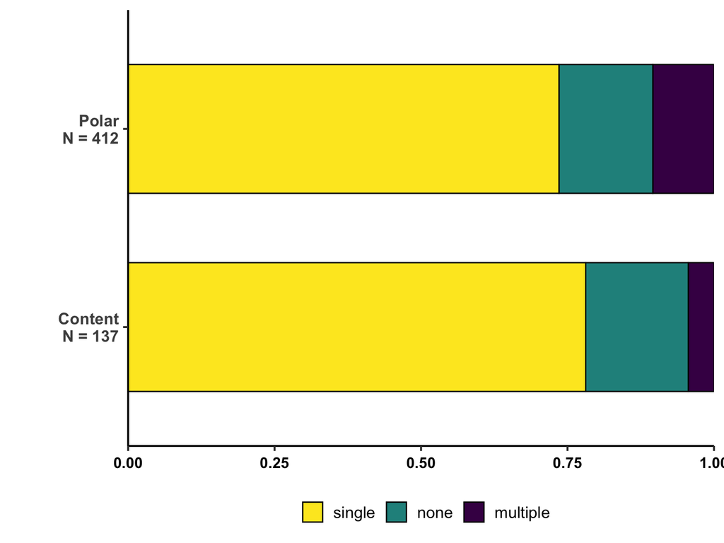

```r
# Aesthetics, geoms, and coord_flip():

eyes_p <- eyes_tab %>%
  mutate(semantic = ifelse(semantic == 'Content',
                           'Content\nN = 137',
                           'Polar\nN = 412')) %>%
  ggplot(aes(x = semantic, y = n, fill = eye_clean)) +
  geom_col(position = 'fill', width = 0.65, col = 'black') +
  coord_flip() +
  scale_fill_viridis_d(guide = guide_legend(reverse = TRUE))

# Cosmetic characteristics:

eyes_p <- eyes_p +
  xlab('') +
  ylab(NULL) +
  scale_y_continuous(expand = c(0, 0)) +
  theme_BSL() +
  theme(legend.position = 'bottom',
        legend.title = element_blank(),
        axis.text.y = element_text(face = 'bold'))

# Show plot:

eyes_p
```

Also a plot of singles only:

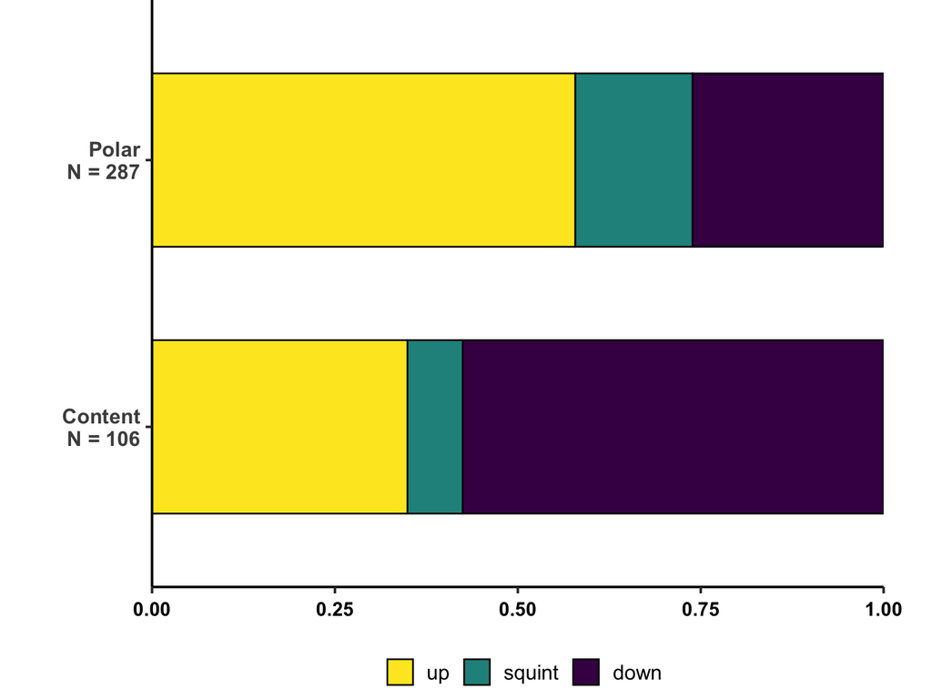

```r
# Aesthetics, geoms, and coord_flip():

singles_p <- singles_tab %>%
  mutate(semantic = ifelse(semantic == 'Content',
                           'Content\nN = 106',
                           'Polar\nN = 287')) %>%
  ggplot(aes(x = semantic, y = n, fill = eye_n_brow)) +
  geom_col(position = 'fill', width = 0.65, col = 'black') +
  coord_flip() +
  scale_fill_viridis_d(guide = guide_legend(reverse = TRUE))

# Cosmetic characteristics:

singles_p <- singles_p +
  xlab('') +
  ylab(NULL) +
  scale_y_continuous(expand = c(0, 0)) +
  theme_BSL() +
  theme(legend.position = 'bottom',
        legend.title = element_blank(),
        axis.text.y = element_text(face = 'bold'),
        plot.margin = margin(r = 30))

# Show plot:

singles_p
```

Put into double plot with eyes:

```r
eyes_p <- eyes_p +
  ggtitle('(a) Eyebrow movements')
singles_p <- singles_p +
  ggtitle('(b) Questions with only one movement')

# Combine:

eyes_double_p <- eyes_p +
  plot_spacer() +
  singles_p +
  plot_layout(widths = c(20, 0.5, 20), nrow = 1)

# Save:

ggsave(plot = eyes_double_p,
       filename = '../figures/pdf/eyes_double_plot.pdf',
       width = 13, height = 3.5)
ggsave(plot = eyes_double_p,
       filename = '../figures/png/eyes_double_plot.png',
       width = 13, height = 3.5)
```

Clean the head movement column:

```r
df <- mutate(df,
             head = str_to_lower(head),
             head = str_replace_all(head, 'hs1', 'hs'),
             head = str_replace_all(head, 'nod1', 'nod'))
```

First, check whether there are single or multiple head movements. For this we first need to simplify the head variable:

```r
# Make conversions:

df <- mutate(df,
             head = ifelse(head == 'nod, null', 'nod', head),
             head = ifelse(head == 'null, nod', 'nod', head),
             head = ifelse(head == 'hs, null', 'hs', head),
             head = ifelse(head == 'nod, null, nod', 'nod', head),
             head = ifelse(head == 'null, nod, null', 'nod', head),
             head = ifelse(head == 'nod, nod', 'nod', head),
             head = ifelse(head == 'backward, null', 'backward', head),
             head = ifelse(head == 'forward, null', 'forward', head),
             head = ifelse(head == 'null, down, null', 'down', head),
             head = ifelse(head == 'nod, nod, null', 'nod', head),
             head = ifelse(head == 'null, forward, null', 'forward', head),
             head = ifelse(head == 'null, hs', 'hs', head),
             head = ifelse(head == 'null, nod, nod', 'nod', head),
             head = ifelse(head == 'null, sideward', 'sideward', head),
             head = ifelse(head == 'down, null', 'down', head),
             head = ifelse(head == 'nod, null, nod, null, nod', 'nod', head),
             head = ifelse(head == 'null, down', 'down', head),
             head = ifelse(head == 'null, nod?', 'nod', head),
             head = ifelse(head == 'null, null', 'null', head),
             head = ifelse(head == 'null, sideward, null', 'sideward', head),
             head = ifelse(head == 'up, null', 'up', head),
             head = ifelse(head == 'not clear', NA, head),
             head = ifelse(head == 'null', 'none', head),
             head = ifelse(head == 'null, forward', 'forward', head),
             head = ifelse(head == 'hs', 'headshake', head))

# Vector of singles:

singles <- c('nod', 'forward', 'headshake',
             'sideward', 'down', 'up', 'backward')

# Create the single versus multiple versus none variable

df <- mutate(df,
             head_type = ifelse(head %in% singles, 'single', head),
             head_type = ifelse(head_type == 'single' | head_type == 'none', head_type, 'multiple'))
```

Now create the counts:

```r
head_type_tab <- df %>%
  count(semantic, head_type) %>%
  filter(!is.na(head_type)) %>%
  group_by(semantic) %>%
  prop_table()

# Show:

head_type_tab
```

```
## # A tibble: 6 × 6
## # Groups:   semantic [2]
##   semantic head_type     n proportion percent N
##   <chr>    <chr>     <int>      <dbl> <chr>   <chr>
## 1 Content  multiple      4       0.03 3%      N = 4
## 2 Content  none         58       0.42 42%     N = 58
## 3 Content  single       77       0.55 55%     N = 77
## 4 Polar    multiple     50       0.12 12%     N = 50
## 5 Polar    none        125       0.3  30%     N = 125
## 6 Polar    single      241       0.58 58%     N = 241
```

Make a plot of this:

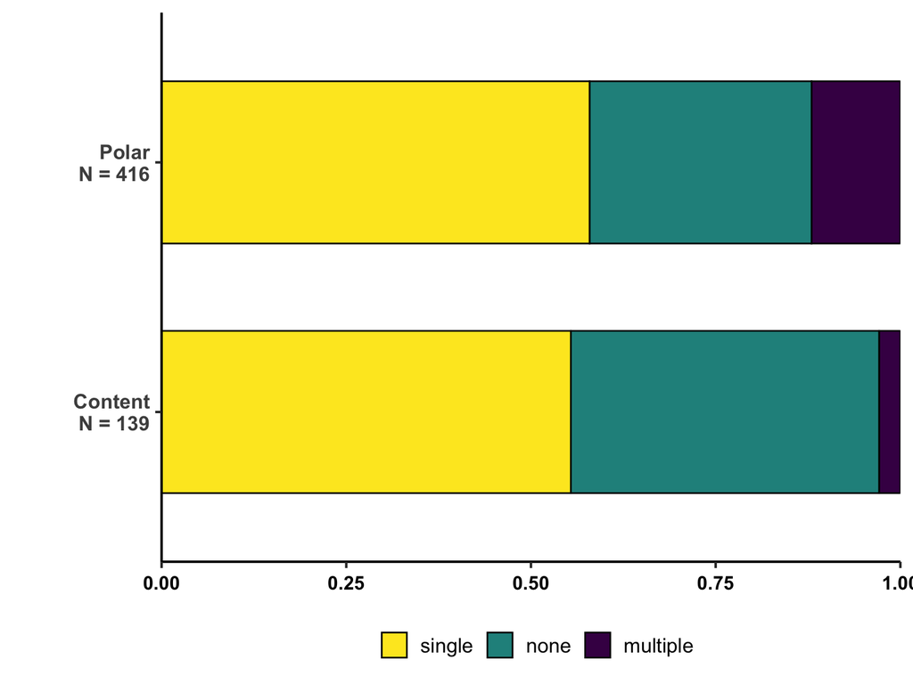

```r
# Aesthetics, geoms, and coord_flip():

head_type_p <- head_type_tab %>%
  mutate(semantic = ifelse(semantic == 'Content',
                           'Content\nN = 139',
                           'Polar\nN = 416')) %>%
  ggplot(aes(x = semantic, y = n, fill = head_type)) +
  geom_col(position = 'fill', width = 0.65, col = 'black') +
  coord_flip() +
  scale_fill_viridis_d(guide = guide_legend(reverse = TRUE))

# Cosmetic characteristics:

head_type_p <- head_type_p +
  xlab('') +
  ylab(NULL) +
  scale_y_continuous(expand = c(0, 0)) +
  theme_BSL() +
  theme(legend.position = 'bottom',
        legend.title = element_blank(),
        axis.text.y = element_text(face = 'bold'))

# Show plot:

head_type_p
```

What head movements are attested? For this, we will set the head variable to “Forward”, “Backward”, “Down”, “Nod”, and “Neither Forward nor Backward”.

Following changes will be done:

- Null = ‘none’
- Nod + Nod1 = ‘nod’

… one category I added on top of the plot in the presentation is “Sideward” because it is quite frequent…

```r
head_singles_tab <- df %>%
  filter(head_type == 'single') %>%
  count(semantic, head) %>%
  group_by(semantic) %>%
  prop_table()

# Show:

head_singles_tab
```

```
## # A tibble: 14 × 6
## # Groups:   semantic [2]
##    semantic head          n proportion percent N
##    <chr>    <chr>     <int>      <dbl> <chr>   <chr>
##  1 Content  backward      2       0.03 3%      N = 2
##  2 Content  down          8       0.1  10%     N = 8
##  3 Content  forward      18       0.23 23%     N = 18
##  4 Content  headshake    11       0.14 14%     N = 11
##  5 Content  nod          22       0.29 29%     N = 22
##  6 Content  sideward     13       0.17 17%     N = 13
##  7 Content  up            3       0.04 4%      N = 3
##  8 Polar    backward      6       0.02 2%      N = 6
##  9 Polar    down         17       0.07 7%      N = 17
## 10 Polar    forward      36       0.15 15%     N = 36
## 11 Polar    headshake    32       0.13 13%     N = 32
## 12 Polar    nod         122       0.51 51%     N = 122
## 13 Polar    sideward     21       0.09 9%      N = 21
## 14 Polar    up            7       0.03 3%      N = 7
```

There are very few up and backward. Let’s exclude them for plotting as these will be impossible to see anyway:

```r
head_singles_tab <- df %>%
  filter(head_type == 'single',
         head != 'backward',
         head != 'up') %>%
  count(semantic, head) %>%
  group_by(semantic) %>%
  prop_table()

# Show:

head_singles_tab
```

```
## # A tibble: 10 × 6
## # Groups:   semantic [2]
##    semantic head          n proportion percent N
##    <chr>    <chr>     <int>      <dbl> <chr>   <chr>
##  1 Content  down          8       0.11 11%     N = 8
##  2 Content  forward      18       0.25 25%     N = 18
##  3 Content  headshake    11       0.15 15%     N = 11
##  4 Content  nod          22       0.31 31%     N = 22
##  5 Content  sideward     13       0.18 18%     N = 13
##  6 Polar    down         17       0.07 7%      N = 17
##  7 Polar    forward      36       0.16 16%     N = 36
##  8 Polar    headshake    32       0.14 14%     N = 32
##  9 Polar    nod         122       0.54 54%     N = 122
## 10 Polar    sideward     21       0.09 9%      N = 21
```

Stacked bar plot for head movements as a function of polar v content:

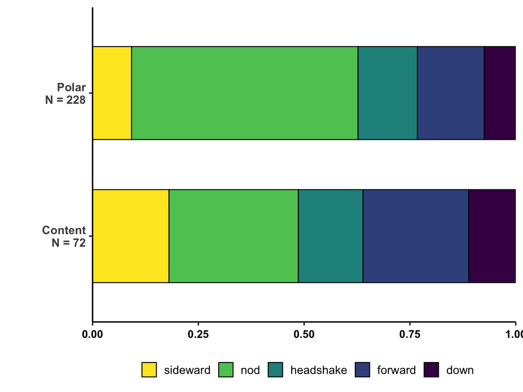

```r
# Aesthetics, geoms, and coord_flip():

head_p <- head_singles_tab %>%
  mutate(semantic = ifelse(semantic == 'Content',
                           'Content\nN = 72',
                           'Polar\nN = 228')) %>%
  ggplot(aes(x = semantic, y = n,
             fill = head)) +
  geom_col(position = 'fill',
           width = 0.65, col = 'black') +
  coord_flip() +
  scale_fill_viridis_d(guide = guide_legend(reverse = TRUE))

# Cosmetic characteristics:

head_p <- head_p +
  xlab('') +
  ylab(NULL) +
  scale_y_continuous(expand = c(0, 0)) +
  theme_BSL() +
  theme(legend.position = 'bottom',
        legend.title = element_blank(),
        axis.text.y = element_text(face = 'bold'))

# Show and save plot:

head_p
```

```r
ggsave(plot = head_p + theme(plot.margin = margin(r = 20)) + ggtitle("Head movements"),
       filename = '../figures/pdf/head_movements_only.pdf',
       width = 7, height = 4)
ggsave(plot = head_p + theme(plot.margin = margin(r = 20)) + ggtitle("Head movements"),
       filename = '../figures/png/head_movements_only.png',
       width = 7, height = 4)
```

Put both together into a double plot:

```r
head_type_p <- head_type_p +
  ggtitle('(a) Head movements')
head_p <- head_p +
  ggtitle('(b) Questions with only one movement') +
  theme(plot.margin = margin(r = 30))

# Combine:

head_double_p <- head_type_p +
  plot_spacer() +
  head_p +
  plot_layout(widths = c(20, 0.5, 20), nrow = 1)

# Save:

ggsave(plot = head_double_p,
       filename = '../figures/pdf/head_double_plot.pdf',
       width = 13, height = 3.5)
ggsave(plot = head_double_p,
       filename = '../figures/png/head_double_plot.png',
       width = 13, height = 3.5)
```

## Multi-strategy marking

In this section, we look at questions that are marked using multiple linguistic signalling strategies. The issue here is that I don’t know how to incorporate head movements and eye movements into this — what counts as a head movement or an eye movement that marks a question? I guess that’s the crux of things anyway since we don’t want to impose an understanding here but want to let that emerge from the bottom-up. Mmmhmh. But anyway, for the following three easily “countable” features, I will do a “semiotic strategy” count, e.g., a question that is marked manually as well as with mouthing gets = 2 strategies.

Also, the codebook does not yet specify what counts as ‘nonmanual’ (whether head and eye movements are included in this count, so not 100% sure if I am double counting something here).

We use 0/1 variables here for easy summing (these will be discarded later).

```r
df <- df %>%
  mutate(mouth_gesture_01 = ifelse(mouth_gesture_question == 'yes', 1, 0),
         any_mouthing_01 = ifelse(any_mouthing == 'yes', 1, 0),
         manual_01 = ifelse(manual == 'Absent', 0, 1),
         nonmanual_01 = ifelse(nonmanual == 'Absent', 0, 1),
         any_head_movement_01 = ifelse(any_head_movement == 'no', 0, 1),
         any_eye_brow_01 = ifelse(any_eye_brow == 'no', 0, 1)) %>%

  # compute strategy count:

  mutate(strategy_count = mouth_gesture_01 +
           any_mouthing_01 +
           manual_01 +
           any_eye_brow_01 +
           any_head_movement_01) %>%

  # get rid of _01 helper variables:
  select(-mouth_gesture_01,
         -any_mouthing_01,
         -manual_01,
         -any_eye_brow_01,
         -any_head_movement_01)
```

Count this:

```r
strat_tab <- df %>%
  count(strategy_count, sort = TRUE) %>%
  prop_table()

# Show:

strat_tab
```

```
## # A tibble: 6 × 5
##   strategy_count     n proportion percent N
##            <dbl> <int>      <dbl> <chr>   <chr>
## 1              2   250       0.45 45%     N = 250
## 2              1   124       0.22 22%     N = 124
## 3              3    94       0.17 17%     N = 94
## 4              4    57       0.1  10%     N = 57
## 5              0    28       0.05 5%      N = 28
## 6              5     3       0.01 1%      N = 3
```

How many had more than one?

```r
df %>%
  mutate(multi_strategy = ifelse(strategy_count >= 2, 'multiple', strategy_count),
         multi_strategy = ifelse(multi_strategy == 1, 'one', multi_strategy)) %>%
  count(multi_strategy, sort = TRUE) %>%
  prop_table()
```

```
## # A tibble: 3 × 5
##   multi_strategy     n proportion percent N
##   <chr>          <int>      <dbl> <chr>   <chr>
## 1 multiple         404       0.73 73%     N = 404
## 2 one              124       0.22 22%     N = 124
## 3 0                 28       0.05 5%      N = 28
```

Let’s make a graph of this:

[figure not shown]

```r
# Data and aesthetics:

strategy_p <- strat_tab %>%
  mutate(strategy_count = factor(strategy_count, levels = 0:6)) %>%
  ggplot(aes(x = strategy_count,
             y = proportion, fill = strategy_count))

# Add geoms:

strategy_p <- strategy_p +
  geom_bar(stat = 'identity', col = 'black', width = 0.6) +
  geom_text(aes(label = N), nudge_y = 0.045) +
  geom_label(aes(label = percent), nudge_y = 0.01, fill = 'white')

# Add other plot features:

strategy_p <- strategy_p +
  scale_fill_viridis_d() +
  scale_y_continuous(breaks = seq(0, 1.0, 0.2),
                     limits = c(0, 0.75),
                     expand = c(0, 0)) +
  xlab('') +
  ylab('Proportion') +
  ggtitle('Number of strategies used to signal questions') +
  theme_BSL()

# Plot & save plot:

strategy_p
```

```r
ggsave(plot = strategy_p, file = '../figures/pdf/strategy_count.pdf',
       width = 8, height = 5.5)
ggsave(plot = strategy_p, file = '../figures/png/strategy_count.png',
       width = 8, height = 5.5)
```

Does this differ for semantic type?

```r
df %>%
  mutate(multi_strategy = ifelse(strategy_count >= 2, 'multiple', strategy_count),
         multi_strategy = ifelse(multi_strategy ==1, 'one', multi_strategy)) %>%
  count(semantic, multi_strategy) %>%
  group_by(semantic) %>%
  prop_table()
```

```
## # A tibble: 6 × 6
## # Groups:   semantic [2]
##   semantic multi_strategy     n proportion percent N
##   <chr>    <chr>          <int>      <dbl> <chr>   <chr>
## 1 Content  0                  2       0.01 1%      N = 2
## 2 Content  multiple         130       0.93 93%     N = 130
## 3 Content  one                8       0.06 6%      N = 8
## 4 Polar    0                 26       0.06 6%      N = 26
## 5 Polar    multiple         274       0.66 66%     N = 274
## 6 Polar    one              116       0.28 28%     N = 116
```

## Question sign position

How do polar v content questions differ by question position? I dropped the NAs because they dominate the picture so much and it becomes hard to see what else is going on.

```r
position_tab <- df %>%
  filter(manual %in% c('Single', 'Multiple')) %>%
  count(semantic, position) %>%
  filter(!is.na(position)) %>%
  group_by(semantic) %>%
  prop_table()

# Show:

position_tab
```

```
## # A tibble: 11 × 6
## # Groups:   semantic [2]
##    semantic position                                  n proportion percent N
##    <chr>    <chr>                                 <int>      <dbl> <chr>   <chr>
##  1 Content  other                                    34       0.32 32%     N = …
##  2 Content  post-predicate (non-reprise & clause…    15       0.14 14%     N = …
##  3 Content  post-predicate (non-reprise)             13       0.12 12%     N = …
##  4 Content  pre-predicate                            23       0.22 22%     N = …
##  5 Content  reprise (clause-final)                   14       0.13 13%     N = …
##  6 Content  reprise (non-clause-final)                7       0.07 7%      N = 7
##  7 Polar    other                                    11       0.19 19%     N = …
##  8 Polar    post-predicate (non-reprise & clause…    28       0.47 47%     N = …
##  9 Polar    post-predicate (non-reprise)              2       0.03 3%      N = 2
## 10 Polar    pre-predicate                             4       0.07 7%      N = 4
## 11 Polar    reprise (clause-final)                   14       0.24 24%     N = …
```

Make the stacked bar plot:

[figure not shown]

```r
# Aesthetics, geoms, and coord_flip():

position_p <- position_tab %>%
  mutate(semantic = ifelse(semantic == 'Content',
                           'Content\nN = 106',
                           'Polar\nN = 57')) %>%
  ggplot(aes(x = semantic, y = n, fill = position)) +
  geom_col(position = 'fill',
           width = 0.65, col = 'black') +
  scale_y_continuous(expand = c(0, 0)) +
  coord_flip() +
  scale_fill_viridis_d(guide = guide_legend(reverse = TRUE))

# Cosmetic characteristics:

position_p <- position_p +
  xlab('') +
  ylab(NULL) +
  theme_BSL() +
  theme(legend.position = c(0.25, -0.35),
        legend.box = 'vertical',
        legend.title = element_blank(),
        axis.text.y = element_text(face = 'bold'),
        plot.margin = margin(t = 0, b = 140,
                             r = 15, l = 0)) +
  ggtitle('Position of manual question signs')

# Show and save plot:

position_p
```

```r
ggsave(plot = position_p, file = '../figures/pdf/positions.pdf',
       width = 10, height = 6)
ggsave(plot = position_p, file = '../figures/png/positions.png',
       width = 10, height = 6)
```

Shed light on this pattern by looking at over- and under-representations using Pearson standardized residuals:

```r
chisq_tab <- with(df, table(semantic, position))
round(chisq.test(chisq_tab)$stdres, 1)
```

```
##          position
## semantic  other post-predicate (non-reprise & clause-final)
##   Content   1.9                                        -4.6
##   Polar    -1.9                                         4.6
##          position
## semantic  post-predicate (non-reprise) pre-predicate reprise (clause-final)
##   Content                          1.9           2.4                   -1.8
##   Polar                           -1.9          -2.4                    1.8
##          position
## semantic  reprise (non-clause-final)
##   Content                        2.0
##   Polar                         -2.0
```

## Pragmatic factors

```r
question_tab <- df %>%
  mutate(question = ifelse(str_detect(question, '\\?'),
                           'Uncertain', question),
         question = str_replace(question,
                                '-NR', '')) %>%
  count(semantic, question) %>%
  group_by(semantic) %>%
  prop_table()

# Show:

question_tab
```

```
## # A tibble: 6 × 6
## # Groups:   semantic [2]
##   semantic question       n proportion percent N
##   <chr>    <chr>      <int>      <dbl> <chr>   <chr>
## 1 Content  Continuing    62       0.44 44%     N = 62
## 2 Content  Initiating    76       0.54 54%     N = 76
## 3 Content  Uncertain      2       0.01 1%      N = 2
## 4 Polar    Continuing   249       0.6  60%     N = 249
## 5 Polar    Initiating   166       0.4  40%     N = 166
## 6 Polar    Uncertain      1       0    0%      N = 1
```

```r
response_tab <- df %>%
  count(semantic, elicited_response) %>%
  group_by(semantic) %>%
  prop_table()

# Show:

response_tab
```

```
## # A tibble: 4 × 6
## # Groups:   semantic [2]
##   semantic elicited_response     n proportion percent N
##   <chr>    <chr>             <int>      <dbl> <chr>   <chr>
## 1 Content  no response          22       0.16 16%     N = 22
## 2 Content  response            118       0.84 84%     N = 118
## 3 Polar    no response          46       0.11 11%     N = 46
## 4 Polar    response            370       0.89 89%     N = 370
```

Stacked bar plot for question type as a function of polar v content:

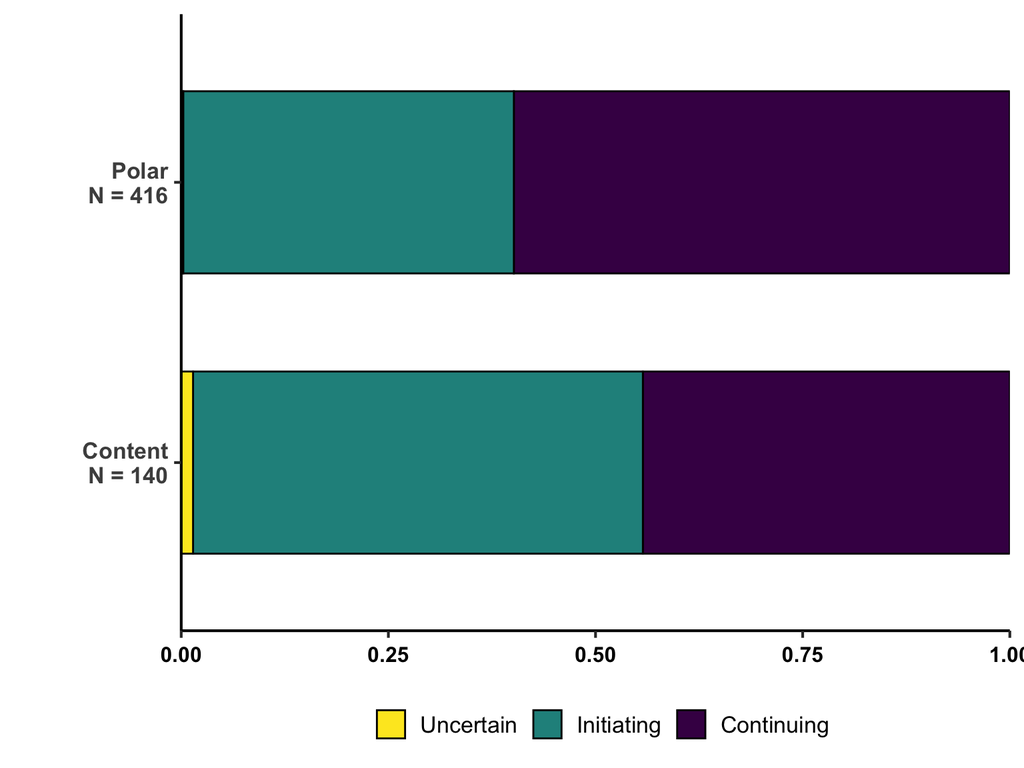

```r
# Aesthetics, geoms, and coord_flip():

question_p <- question_tab %>%
  mutate(semantic = ifelse(semantic == 'Content',
                           'Content\nN = 140',
                           'Polar\nN = 416')) %>%
  ggplot(aes(x = semantic, y = n, fill = question)) +
  geom_col(position = 'fill', width = 0.65, col = 'black') +
  coord_flip() +
  scale_fill_viridis_d(guide = guide_legend(reverse = TRUE))

# Cosmetic characteristics:

question_p <- question_p +
  xlab('') +
  ylab(NULL) +
  scale_y_continuous(expand = c(0, 0)) +
  theme_BSL() +
  theme(legend.position = 'bottom',
        legend.title = element_blank(),
        axis.text.y = element_text(face = 'bold'))

# Show plot:

question_p
```

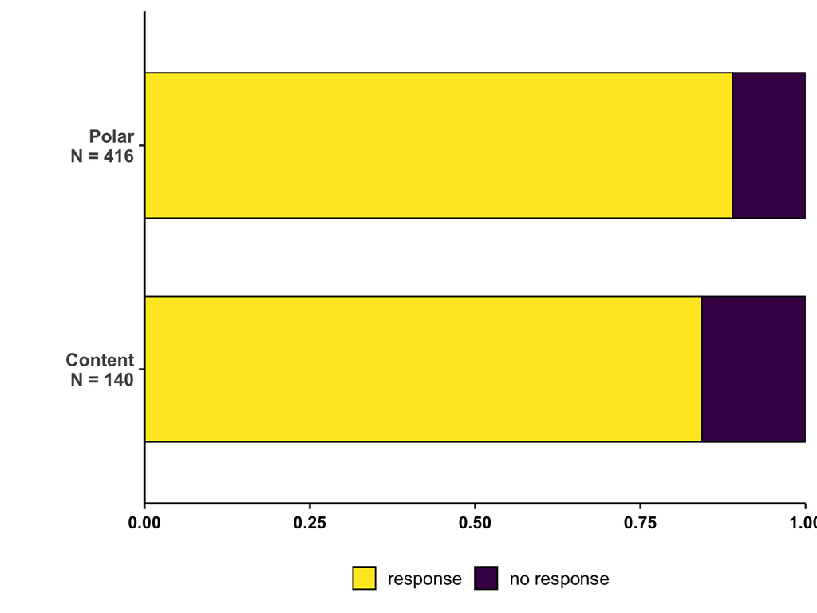

```r
# Aesthetics, geoms, and coord_flip():

response_p <- response_tab %>%
  mutate(semantic = ifelse(semantic == 'Content',
                           'Content\nN = 140',
                           'Polar\nN = 416')) %>%
  ggplot(aes(x = semantic, y = n,
             fill = elicited_response)) +
  geom_col(position = 'fill',
           width = 0.65, col = 'black') +
  coord_flip() +
  scale_fill_viridis_d(guide = guide_legend(reverse = TRUE))

# Cosmetic characteristics:

response_p <- response_p +
  xlab('') +
  ylab(NULL) +
  scale_y_continuous(expand = c(0, 0)) +
  theme_BSL() +
  theme(legend.position = 'bottom',
        legend.title = element_blank(),
        axis.text.y = element_text(face = 'bold'))

# Show and save plot:

response_p
```

```r
# New titles with a) and b):

question_p <- question_p +
  ggtitle('(a) Question type')
response_p <- response_p +
  ggtitle('(b) Requested response')

# Combine:

response_double_p <- question_p +
  plot_spacer() +
  response_p +
  plot_layout(widths = c(20, 0.5, 20), nrow = 1)

ggsave(plot = response_double_p,
       filename = '../figures/pdf/question_response.pdf',
       width = 13, height = 3.5)
ggsave(plot = response_double_p,
       filename = '../figures/png/question_response.png',
       width = 13, height = 3.5)
```

## Sociolinguistics: Deafness in family

First, let’s look at whether they are from deaf families or not, for each of the features (disregarding polars vs. contents for now).

Manual features:

```r
df %>%
  count(family, manual) %>%
  group_by(family) %>%
  prop_table()
```

```
## # A tibble: 6 × 6
## # Groups:   family [2]
##   family  manual       n proportion percent N
##   <chr>   <chr>    <int>      <dbl> <chr>   <chr>
## 1 Deaf    Absent     149       0.68 68%     N = 149
## 2 Deaf    Multiple    16       0.07 7%      N = 16
## 3 Deaf    Single      53       0.24 24%     N = 53
## 4 Hearing Absent     242       0.72 72%     N = 242
## 5 Hearing Multiple    29       0.09 9%      N = 29
## 6 Hearing Single      67       0.2  20%     N = 67
```

Almost exactly the same.

Nonmanuals by deaf/hearing family:

```r
df %>%
  count(family, nonmanual) %>%
  group_by(family) %>%
  prop_table()
```

```
## # A tibble: 4 × 6
## # Groups:   family [2]
##   family  nonmanual     n proportion percent N
##   <chr>   <chr>     <int>      <dbl> <chr>   <chr>
## 1 Deaf    Absent        7       0.03 3%      N = 7
## 2 Deaf    Present     211       0.97 97%     N = 211
## 3 Hearing Absent        5       0.01 1%      N = 5
## 4 Hearing Present     333       0.99 99%     N = 333
```

Almost exactly the same.

Mouthings by deaf/hearing family:

```r
df %>%
  count(family, mouthing_question) %>%
  group_by(family) %>%
  prop_table()
```

```
## # A tibble: 6 × 6
## # Groups:   family [2]
##   family  mouthing_question     n proportion percent N
##   <chr>   <chr>             <int>      <dbl> <chr>   <chr>
## 1 Deaf    Absent              167       0.77 77%     N = 167
## 2 Deaf    Multiple              4       0.02 2%      N = 4
## 3 Deaf    Single               47       0.22 22%     N = 47
## 4 Hearing Absent              271       0.8  80%     N = 271
## 5 Hearing Multiple             14       0.04 4%      N = 14
## 6 Hearing Single               53       0.16 16%     N = 53
```

Basically the same again.

Head movements by deaf/hearing family:

```r
df %>%
  count(family, head) %>%
  group_by(family) %>%
  prop_table() %>%
  pivot_wider(values_from = percent,
              names_from = family,
              id_cols = head) %>%
  print(n = Inf)
```

```
## # A tibble: 48 × 3
##    head                             Deaf  Hearing
##    <chr>                            <chr> <chr>
##  1 backward                         2%    1%
##  2 backward, forward                0%    0%
##  3 backward, forward, backward      0%    <NA>
##  4 down                             6%    4%
##  5 down+hs, null                    0%    <NA>
##  6 down, hs                         0%    0%
##  7 forward                          7%    12%
##  8 forward+hs                       0%    0%
##  9 forward+nod                      0%    <NA>
## 10 headshake                        6%    9%
## 11 hs, forward+hs                   0%    <NA>
## 12 hs, null, nod                    0%    0%
```

[output cut: 36 more lines]

Basically the same again (compare left and right columns, and NA = 0%).

Eyes by family:

```r
df %>%
  count(family, eye_n_brow) %>%
  group_by(family) %>%
  prop_table() %>%
  pivot_wider(values_from = percent,
              names_from = family,
              id_cols = eye_n_brow) %>%
  print(n = Inf)
```

```
## # A tibble: 39 × 3
##    eye_n_brow             Deaf  Hearing
##    <chr>                  <chr> <chr>
##  1 down                   20%   22%
##  2 down, null             2%    1%
##  3 down, up               3%    2%
##  4 not visible            3%    <NA>
##  5 null                   17%   16%
##  6 null, down             2%    1%
##  7 null, down, null       0%    0%
##  8 null, down, up         0%    <NA>
##  9 null, squint           1%    1%
## 10 null, squint, null     1%    <NA>
## 11 null, up               1%    3%
## 12 null, up, null         1%    1%
```

[output cut: 27 more lines]

Same.

## Sociolinguistics: BSL teaching

Parse the `clu` column into one that can be matched with the participant data:

```r
df <- mutate(df,
             clu = str_sub(clu, 1, 9))
```

First incorporate the data about whether they have or haven’t taught:

```r
ppts <- read_csv('../data/ParticipantSpreadsheet11JUN14ANON.csv')
```

Get the relevant column:

```r
ppts <- select(ppts,
               `Overall code`, `Taught BSL`) %>%
  rename(ID = `Overall code`,
         taught_bsl = `Taught BSL`)
```

Get rid of missing rows at the bottom of the file:

```r
ppts <- filter(ppts, !is.na(ID))
```

Merge the `ppts` BSL teaching data into the `df` tibble:

```r
# Check that they all match:

all(!is.na(match(df$clu, ppts$ID)))
```

```
## [1] TRUE
```

They do. So let’s merge it in:

```r
df <- left_join(df, ppts,
                by = c('clu' = 'ID'))
```

Check:

```r
df$taught_bsl
```

```
##   [1] "Y" "Y" "Y" "Y" "Y" "Y" "Y" "Y" "Y" "Y" "Y" "Y" "Y" "Y" "Y" "Y" "Y" "Y"
##  [19] "Y" "Y" "Y" "Y" "Y" "Y" NA  NA  NA  NA  NA  NA  NA  NA  NA  NA  NA  NA
##  [37] NA  NA  NA  NA  NA  NA  NA  NA  NA  NA  "N" "N" "N" "N" "N" "N" "N" "N"
##  [55] "N" "N" "N" "N" "N" "N" "N" "N" "N" "N" "N" "Y" "Y" "Y" "Y" "Y" "Y" "Y"
##  [73] NA  NA  NA  NA  NA  NA  NA  NA  NA  NA  NA  NA  NA  NA  "N" "N" "N" "N"
##  [91] NA  NA  NA  NA  NA  NA  NA  NA  NA  NA  NA  NA  NA  NA  NA  NA  NA  NA
## [109] NA  NA  NA  NA  NA  NA  NA  NA  NA  NA  NA  NA  NA  NA  NA  NA  NA  NA
## [127] NA  NA  NA  NA  NA  NA  NA  NA  NA  NA  NA  NA  NA  NA  NA  NA  NA  NA
## [145] NA  NA  NA  NA  NA  NA  NA  NA  NA  NA  NA  NA  NA  NA  NA  NA  "N" "N"
## [163] "N" "N" "N" "N" "N" "N" "N" "N" "N" "N" "N" "N" "N" "N" "N" "N" "N" "N"
## [181] "N" "Y" "Y" "Y" "Y" "Y" NA  NA  NA  NA  NA  NA  NA  NA  NA  NA  NA  NA
## [199] NA  NA  NA  NA  "Y" "Y" "Y" "Y" "Y" "Y" "Y" "Y" "Y" "Y" "Y" "Y" "Y" "Y"
## [217] "Y" "Y" NA  NA  NA  NA  NA  NA  NA  NA  NA  NA  NA  NA  NA  NA  NA  NA
## [235] NA  NA  NA  NA  NA  NA  NA  NA  NA  NA  NA  NA  NA  NA  NA  NA  NA  NA
## [253] NA  NA  NA  NA  NA  NA  NA  NA  NA  NA  NA  NA  NA  NA  NA  NA  NA  NA
```

[output cut: 16 more lines]

Create a subset with only those that have “Y” and “N” (rather than no information available):

```r
teaching <- filter(df,
                   taught_bsl %in% c('Y', 'N'))
```

Ok, so let’s check the BSL teaching variable for the different features:

Manual features:

```r
teaching %>%
  count(taught_bsl, manual) %>%
  group_by(taught_bsl) %>%
  prop_table()
```

```
## # A tibble: 6 × 6
## # Groups:   taught_bsl [2]
##   taught_bsl manual       n proportion percent N
##   <chr>      <chr>    <int>      <dbl> <chr>   <chr>
## 1 N          Absent     118       0.69 69%     N = 118
## 2 N          Multiple    13       0.08 8%      N = 13
## 3 N          Single      39       0.23 23%     N = 39
## 4 Y          Absent      65       0.57 57%     N = 65
## 5 Y          Multiple    14       0.12 12%     N = 14
## 6 Y          Single      36       0.31 31%     N = 36
```

Very similar, but let’s check standardized residuals:

```r
manual_teach_tab <- with(teaching, table(taught_bsl, manual))
round(chisq.test(manual_teach_tab)$stdres, 2)
```

```
##           manual
## taught_bsl Absent Multiple Single
##          N   2.23    -1.28  -1.57
##          Y  -2.23     1.28   1.57
```

```r
cramersV(manual_teach_tab) # negligible effect
```

```
## [1] 0.1335348
```

A slightly higher tendency for teachers to use manual signals, but not particularly reliable / strong at all.

Nonmanuals by teaching:

```r
teaching %>%
  count(taught_bsl, nonmanual) %>%
  group_by(taught_bsl) %>%
  prop_table()
```

```
## # A tibble: 4 × 6
## # Groups:   taught_bsl [2]
##   taught_bsl nonmanual     n proportion percent N
##   <chr>      <chr>     <int>      <dbl> <chr>   <chr>
## 1 N          Absent        3       0.02 2%      N = 3
## 2 N          Present     167       0.98 98%     N = 167
## 3 Y          Absent        2       0.02 2%      N = 2
## 4 Y          Present     113       0.98 98%     N = 113
```

Almost exactly the same.

Mouthings by teaching:

```r
teaching %>%
  count(taught_bsl, mouthing_question) %>%
  group_by(taught_bsl) %>%
  prop_table()
```

```
## # A tibble: 6 × 6
## # Groups:   taught_bsl [2]
##   taught_bsl mouthing_question     n proportion percent N
##   <chr>      <chr>             <int>      <dbl> <chr>   <chr>
## 1 N          Absent              128       0.75 75%     N = 128
## 2 N          Multiple             10       0.06 6%      N = 10
## 3 N          Single               32       0.19 19%     N = 32
## 4 Y          Absent               90       0.78 78%     N = 90
## 5 Y          Multiple              2       0.02 2%      N = 2
## 6 Y          Single               23       0.2  20%     N = 23
```

Basically the same again.

Head movements by teaching:

```r
teaching %>%
  count(taught_bsl, head) %>%
  group_by(taught_bsl) %>%
  prop_table() %>%
  pivot_wider(values_from = percent,
              names_from = taught_bsl,
              id_cols = head) %>%
  print(n = Inf)
```

```
## # A tibble: 32 × 3
##    head                     N     Y
##    <chr>                    <chr> <chr>
##  1 backward                 1%    3%
##  2 backward, forward        1%    <NA>
##  3 down                     4%    8%
##  4 down, hs                 1%    1%
##  5 forward                  11%   11%
##  6 headshake                10%   6%
##  7 hs, nod                  1%    <NA>
##  8 hs, null, nod, null      1%    <NA>
##  9 nod                      24%   26%
## 10 nod, null, down          1%    <NA>
## 11 none                     40%   21%
## 12 null, forward, nod       1%    <NA>
```

[output cut: 20 more lines]

Eyes by teaching:

```r
teaching %>%
  count(taught_bsl, eye_n_brow) %>%
  group_by(taught_bsl) %>%
  prop_table() %>%
  pivot_wider(values_from = percent,
              names_from = taught_bsl,
              id_cols = eye_n_brow) %>%
  print(n = Inf)
```

```
## # A tibble: 33 × 3
##    eye_n_brow           N     Y
##    <chr>                <chr> <chr>
##  1 down                 22%   19%
##  2 down, down           1%    <NA>
##  3 down, null           1%    3%
##  4 down, squint, null   1%    <NA>
##  5 down, up             4%    2%
##  6 down, up, down       1%    <NA>
##  7 null                 18%   17%
##  8 null, down           1%    5%
##  9 null, squint         1%    2%
## 10 null, squint, null   1%    <NA>
## 11 null, up             4%    1%
## 12 squint               7%    3%
```

[output cut: 21 more lines]

Not much of a difference again.

## Sociolinguistics: Age

Let’s look at age next. For this, let’s perform a median split of the data into old and young for heuristic/explorative purposes.

```r
df <- mutate(df,
             age_cat = ifelse(age > median(age),
                              'old', 'young'))
```

Manual features:

```r
df %>%
  count(age_cat, manual) %>%
  group_by(age_cat) %>%
  prop_table()
```

```
## # A tibble: 6 × 6
## # Groups:   age_cat [2]
##   age_cat manual       n proportion percent N
##   <chr>   <chr>    <int>      <dbl> <chr>   <chr>
## 1 old     Absent     181       0.72 72%     N = 181
## 2 old     Multiple    19       0.08 8%      N = 19
## 3 old     Single      50       0.2  20%     N = 50
## 4 young   Absent     210       0.69 69%     N = 210
## 5 young   Multiple    26       0.08 8%      N = 26
## 6 young   Single      70       0.23 23%     N = 70
```

Almost exactly the same.

Nonmanuals by age category:

```r
df %>%
  count(age_cat, nonmanual) %>%
  group_by(age_cat) %>%
  prop_table()
```

```
## # A tibble: 4 × 6
## # Groups:   age_cat [2]
##   age_cat nonmanual     n proportion percent N
##   <chr>   <chr>     <int>      <dbl> <chr>   <chr>
## 1 old     Absent        1       0    0%      N = 1
## 2 old     Present     249       1    100%    N = 249
## 3 young   Absent       11       0.04 4%      N = 11
## 4 young   Present     295       0.96 96%     N = 295
```

Almost exactly the same.

Mouthings by age category:

```r
df %>%
  count(age_cat, mouthing_question) %>%
  group_by(age_cat) %>%
  prop_table()
```

```
## # A tibble: 6 × 6
## # Groups:   age_cat [2]
##   age_cat mouthing_question     n proportion percent N
##   <chr>   <chr>             <int>      <dbl> <chr>   <chr>
## 1 old     Absent              192       0.77 77%     N = 192
## 2 old     Multiple             12       0.05 5%      N = 12
## 3 old     Single               46       0.18 18%     N = 46
## 4 young   Absent              246       0.8  80%     N = 246
## 5 young   Multiple              6       0.02 2%      N = 6
## 6 young   Single               54       0.18 18%     N = 54
```

Basically the same again.

Head movements by age category:

```r
df %>%
  count(age_cat, head) %>%
  group_by(age_cat) %>%
  prop_table() %>%
  pivot_wider(values_from = percent,
              names_from = age_cat,
              id_cols = head) %>%
  print(n = Inf)
```

```
## # A tibble: 48 × 3
##    head                             old   young
##    <chr>                            <chr> <chr>
##  1 backward                         2%    1%
##  2 backward, hs                     0%    <NA>
##  3 backward, sideward               0%    <NA>
##  4 down                             2%    6%
##  5 down+hs, null                    0%    <NA>
##  6 forward                          8%    11%
##  7 forward+hs                       0%    0%
##  8 forward+nod                      0%    <NA>
##  9 forward, backward                0%    <NA>
## 10 forward, nod                     1%    1%
## 11 headshake                        6%    9%
## 12 hs, forward                      0%    <NA>
```

[output cut: 36 more lines]

Older speaker slightly more likely to have “Null” than younger speakers.

Eyes by age category:

```r
df %>%
  count(age_cat, eye_n_brow) %>%
  group_by(age_cat) %>%
  prop_table() %>%
  pivot_wider(values_from = percent,
              names_from = age_cat,
              id_cols = eye_n_brow) %>%
  print(n = Inf)
```

```
## # A tibble: 39 × 3
##    eye_n_brow             old   young
##    <chr>                  <chr> <chr>
##  1 down                   20%   22%
##  2 down, down             0%    <NA>
##  3 down, null             1%    2%
##  4 down, squint, null     0%    <NA>
##  5 down, up               2%    2%
##  6 not visible            3%    <NA>
##  7 null                   16%   16%
##  8 null, down             3%    1%
##  9 null, down, null       0%    0%
## 10 null, down, up         0%    <NA>
## 11 null, squint           0%    2%
## 12 null, squint, null     0%    0%
```

[output cut: 27 more lines]

No big differences here.

## Sociolinguistics: Gender

Let’s look at gender next. First, manual signaling:

```r
df %>%
  count(gender, manual) %>%
  group_by(gender) %>%
  prop_table()
```

```
## # A tibble: 6 × 6
## # Groups:   gender [2]
##   gender manual       n proportion percent N
##   <chr>  <chr>    <int>      <dbl> <chr>   <chr>
## 1 F      Absent     233       0.71 71%     N = 233
## 2 F      Multiple    30       0.09 9%      N = 30
## 3 F      Single      67       0.2  20%     N = 67
## 4 M      Absent     158       0.7  70%     N = 158
## 5 M      Multiple    15       0.07 7%      N = 15
## 6 M      Single      53       0.23 23%     N = 53
```

Almost exactly the same.

Next, nonmanuals by gender:

```r
df %>%
  count(gender, nonmanual) %>%
  group_by(gender) %>%
  prop_table()
```

```
## # A tibble: 4 × 6
## # Groups:   gender [2]
##   gender nonmanual     n proportion percent N
##   <chr>  <chr>     <int>      <dbl> <chr>   <chr>
## 1 F      Absent        7       0.02 2%      N = 7
## 2 F      Present     323       0.98 98%     N = 323
## 3 M      Absent        5       0.02 2%      N = 5
## 4 M      Present     221       0.98 98%     N = 221
```

Almost exactly the same.

Next, mouthings by gender:

```r
df %>%
  count(gender, mouthing_question) %>%
  group_by(gender) %>%
  prop_table()
```

```
## # A tibble: 6 × 6
## # Groups:   gender [2]
##   gender mouthing_question     n proportion percent N
##   <chr>  <chr>             <int>      <dbl> <chr>   <chr>
## 1 F      Absent              258       0.78 78%     N = 258
## 2 F      Multiple             10       0.03 3%      N = 10
## 3 F      Single               62       0.19 19%     N = 62
## 4 M      Absent              180       0.8  80%     N = 180
## 5 M      Multiple              8       0.04 4%      N = 8
## 6 M      Single               38       0.17 17%     N = 38
```

Basically the same again.

Head movements by gender:

```r
df %>%
  count(gender, head) %>%
  group_by(gender) %>%
  prop_table() %>%
  pivot_wider(values_from = percent,
              names_from = gender,
              id_cols = head) %>%
  print(n = Inf)
```

```
## # A tibble: 48 × 3
##    head                             F     M
##    <chr>                            <chr> <chr>
##  1 backward                         2%    0%
##  2 backward, forward                1%    <NA>
##  3 backward, forward, backward      0%    <NA>
##  4 backward, hs                     0%    <NA>
##  5 backward, nod                    0%    <NA>
##  6 down                             4%    5%
##  7 down+hs                          0%    <NA>
##  8 down+hs, null                    0%    <NA>
##  9 down, hs                         0%    0%
## 10 forward                          9%    11%
## 11 forward+hs                       1%    <NA>
## 12 forward+nod                      0%    <NA>
```

[output cut: 36 more lines]

Eyes by gender:

```r
df %>%
  count(gender, eye_n_brow) %>%
  group_by(gender) %>%
  prop_table() %>%
  pivot_wider(values_from = percent,
              names_from = gender,
              id_cols = eye_n_brow) %>%
  print(n = Inf)
```

```
## # A tibble: 39 × 3
##    eye_n_brow             F     M
##    <chr>                  <chr> <chr>
##  1 down                   22%   20%
##  2 down+squint            1%    <NA>
##  3 down, down             0%    <NA>
##  4 down, null             2%    1%
##  5 down, squint, null     0%    <NA>
##  6 down, up               2%    3%
##  7 down, up, down         0%    0%
##  8 down, up, up, up, down 0%    <NA>
##  9 neutral                0%    <NA>
## 10 not visible            2%    <NA>
## 11 null                   15%   18%
## 12 null, down             1%    3%
```

[output cut: 27 more lines]

## Sociolinguistics: Location

Finally, location. First, check whether the proportion of polar/content is different:

```r
polar_location_tab <- with(df, table(semantic, location))

polar_location_tab
```

```
##          location
## semantic  Birmingham Bristol London Manchester
##   Content         34      35     30         41
##   Polar          118      82     98        118
```

```r
round(prop.table(polar_location_tab, margin = 1), 2) # row-wise proportions
```

```
##          location
## semantic  Birmingham Bristol London Manchester
##   Content       0.24    0.25   0.21       0.29
##   Polar         0.28    0.20   0.24       0.28
```

Mostly similar. This is important for interpreting what follows.

Manual features:

```r
df %>%
  count(location, manual) %>%
  group_by(location) %>%
  prop_table() %>%
  pivot_wider(id_cols = location,
              values_from = percent,
              names_from = manual)
```

```
## # A tibble: 4 × 4
## # Groups:   location [4]
##   location   Absent Multiple Single
##   <chr>      <chr>  <chr>    <chr>
## 1 Birmingham 83%    3%       14%
## 2 Bristol    54%    11%      35%
## 3 London     62%    14%      24%
## 4 Manchester 77%    6%       17%
```

Birmingham and Manchester speakers less likely to use manual signs. Quite a noteworthy difference. Let’s check this with standardized residuals and effect size:

```r
location_manual_tab <- with(df, table(location, manual))

cramersV(location_manual_tab) # small to medium effect size
```

```
## [1] 0.1870104
```

```r
round(chisq.test(location_manual_tab)$stdres, 1) # yes, birmingham and Manchester over-represented
```

```
##             manual
## location     Absent Multiple Single
##   Birmingham    4.0     -2.5   -2.7
##   Bristol      -4.4      1.3    4.0
##   London       -2.4      2.8    0.8
##   Manchester    2.3     -1.3   -1.7
```

Nonmanuals by location:

```r
df %>%
  count(location, nonmanual) %>%
  group_by(location) %>%
  prop_table()
```

```
## # A tibble: 8 × 6
## # Groups:   location [4]
##   location   nonmanual     n proportion percent N
##   <chr>      <chr>     <int>      <dbl> <chr>   <chr>
## 1 Birmingham Absent        1       0.01 1%      N = 1
## 2 Birmingham Present     151       0.99 99%     N = 151
## 3 Bristol    Absent        4       0.03 3%      N = 4
## 4 Bristol    Present     113       0.97 97%     N = 113
## 5 London     Absent        1       0.01 1%      N = 1
## 6 London     Present     127       0.99 99%     N = 127
## 7 Manchester Absent        6       0.04 4%      N = 6
## 8 Manchester Present     153       0.96 96%     N = 153
```

Almost exactly the same.

Mouthings by location:

```r
df %>%
  count(location, mouthing_question) %>%
  group_by(location) %>%
  prop_table()
```

```
## # A tibble: 12 × 6
## # Groups:   location [4]
##    location   mouthing_question     n proportion percent N
##    <chr>      <chr>             <int>      <dbl> <chr>   <chr>
##  1 Birmingham Absent              127       0.84 84%     N = 127
##  2 Birmingham Multiple              3       0.02 2%      N = 3
##  3 Birmingham Single               22       0.14 14%     N = 22
##  4 Bristol    Absent               90       0.77 77%     N = 90
##  5 Bristol    Multiple              3       0.03 3%      N = 3
##  6 Bristol    Single               24       0.21 21%     N = 24
##  7 London     Absent              101       0.79 79%     N = 101
##  8 London     Multiple              3       0.02 2%      N = 3
##  9 London     Single               24       0.19 19%     N = 24
## 10 Manchester Absent              120       0.75 75%     N = 120
## 11 Manchester Multiple              9       0.06 6%      N = 9
## 12 Manchester Single               30       0.19 19%     N = 30
```

Check:

```r
location_mouthing_tab <- with(df, table(location, mouthing_question))

cramersV(location_mouthing_tab) # negligible effect size
```

```
## [1] 0.07582184
```

```r
round(chisq.test(location_mouthing_tab)$stdres, 1) # yes, birmingham and Manchester over-represented
```

```
##             mouthing_question
## location     Absent Multiple Single
##   Birmingham    1.7     -1.0   -1.3
##   Bristol      -0.6     -0.5    0.8
##   London        0.0     -0.7    0.3
##   Manchester   -1.2      2.0    0.3
```

Head movements by location:

```r
df %>%
  count(location, head) %>%
  group_by(location) %>%
  prop_table() %>%
  pivot_wider(values_from = percent,
              names_from = location,
              id_cols = head) %>%
  print(n = Inf)
```

```
## # A tibble: 48 × 5
##    head                             Birmingham Bristol London Manchester
##    <chr>                            <chr>      <chr>   <chr>  <chr>
##  1 backward                         1%         3%      1%     1%
##  2 backward, forward                1%         <NA>    <NA>   1%
##  3 backward, forward, backward      1%         <NA>    <NA>   <NA>
##  4 down                             3%         7%      8%     1%
##  5 forward                          5%         14%     12%    10%
##  6 forward, backward, nod, nod, nod 1%         <NA>    <NA>   <NA>
##  7 headshake                        6%         8%      8%     9%
##  8 nod                              23%        31%     29%    23%
##  9 nod, backward, sideward          1%         <NA>    <NA>   <NA>
## 10 nod, hs                          1%         <NA>    <NA>   <NA>
## 11 nod, null, down                  1%         <NA>    1%     <NA>
## 12 nod, sideward                    1%         <NA>    <NA>   <NA>
```

[output cut: 36 more lines]

Birmingham and Manchester more likely to have “Null”.

Eyes by Location:

```r
df %>%
  count(location, eye_n_brow) %>%
  group_by(location) %>%
  prop_table() %>%
  pivot_wider(values_from = percent,
              names_from = location,
              id_cols = eye_n_brow) %>%
  print(n = Inf)
```

```
## # A tibble: 39 × 5
##    eye_n_brow             Birmingham Bristol London Manchester
##    <chr>                  <chr>      <chr>   <chr>  <chr>
##  1 down                   18%        26%     26%    17%
##  2 down, up               2%         1%      4%     2%
##  3 down, up, up, up, down 1%         <NA>    <NA>   <NA>
##  4 neutral                1%         <NA>    <NA>   <NA>
##  5 null                   9%         16%     16%    23%
##  6 null, down             1%         5%      2%     <NA>
##  7 null, down, up         1%         <NA>    <NA>   <NA>
##  8 null, squint           1%         2%      1%     1%
##  9 null, squint, null     1%         1%      <NA>   <NA>
## 10 null, up               1%         3%      4%     1%
## 11 squint                 15%        2%      2%     10%
## 12 squint, null           1%         <NA>    <NA>   1%
```

[output cut: 27 more lines]

Bristol and London more likely to look down, proportionally speaking. Birmingham much more likely to squint. And also look “up”. A bit is going on with “null” as well.

This completes this analysis.